# Vaccines: Many Beliefs Pilot 4

Derek Powell

June 30, 2017

```r
filename <- "vb_pilot4.csv"
headers <- as.matrix(read.csv(filename, skip = 0, header = F, nrows = 1, as.is = T ))
df <- read.csv(filename, skip = 3, header = F)
colnames(df) <- headers
df <- df[which(df$Status==0),] # remove survey previews
# remove unused qualtrics variables
remove_cols <- c("RecipientLastName",
                 "RecipientFirstName",
                 "RecipientEmail",
                 "Finished",
                 "ResponseId",
                 "ExternalReference",
                 "DistributionChannel",
                 "UserLanguage",
                 "Status")
df <- df[ , -which(names(df) %in% remove_cols)]
df <- df[which(df$vaccDanger_check_3==3 & df$hb_check_5==5),]
```

```r
all_items <- c("hb_1",
"hb_2",
"hb_3",
"hb_4",
"nat_1",
"nat_2r",
"nat_3",
"nat_4",
"nat_5r",
"medSkept_1",
"medSkept_2r",
"medSkept_3",
"medSkept_4",
"medSkept_5r",
"diseaseRare_1",
"diseaseRare_2",
"diseaseRare_3r",
"diseaseRare_4",
"diseaseRare_5r",
"diseaseSevere_1",
"diseaseSevere_2",
"diseaseSevere_3r",
"diseaseSevere_4",
"diseaseSevere_5r",
"vaccEff_1",
"vaccEff_2r",
"vaccEff_3r",
"vaccEff_4",
"vaccDanger_1",
"vaccDanger_2r",
"vaccDanger_3",
"vaccDanger_4r",
"vaccTox_1r",
"vaccTox_2",
"vaccTox_3",
"vaccTox_4r",
"vaccStrain_1",
"vaccStrain_2r",
"vaccStrain_3",
"vaccStrain_4r",
"vaccStrain_5",
"vaccIntent_1r",
"vaccIntent_2",
"vaccIntent_3r",
"vaccIntent_4",
"vaccIntent_5r",
"parentExpert_1",
"parentExpert_2",
"parentExpert_3",
"parentExpert_4r",
"parentExpert_5r",
"infantImmLimCap_1",
"infantImmLimCap_2r",
"infantImmLimCap_3",
"infantImmLimCap_4",
"infantImmLimCap_5r",
"infantImmWeak_1",
"infantImmWeak_2",
"infantImmWeak_3",
"infantImmWeak_4r",
"infantImmWeak_5r",
"overpar_1r",
"overpar_2",
"overpar_3",
"overpar_4",
"overpar_5r",
"overpar_6r")
```

```r
library(ggplot2)
# df <- read.csv("vb_pilot2.csv")
reverse_items <- all_items[!sapply(
  lapply(all_items, function (x) {
  if (substr(x,nchar(x),nchar(x))=="r") {
    return(x)
  }
}), is.null)]

df[,reverse_items] <- lapply(df[,reverse_items], function(x) {
  8-x
})
df_main <- df[,all_items]
```

# Introduction

This is a notebook for the fourth pilot experiment of our (Kara, Ellen, and Derek) first pilot experiment examining vaccine theories using multiple attitude measures. We recruited 100 participants and lost 1 to comprehension checks, leaving 99.

# Item Correlations

Here’s a correlation matrix for all individual items. It appears items of some scales are intercorrelating well, though others are weaker. There is also considerable correlation among items across scales–as we might expect.

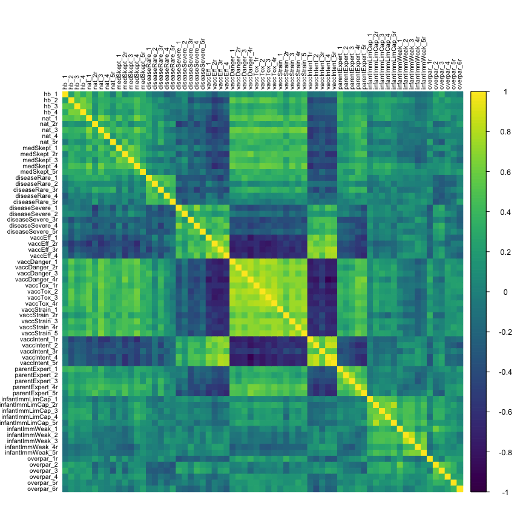

```r
library(corrplot)
library(viridis)
corrplot(cor(df_main),
         tl.cex=.65,
         tl.col="black",
         method="color",
         col=viridis(128))
```

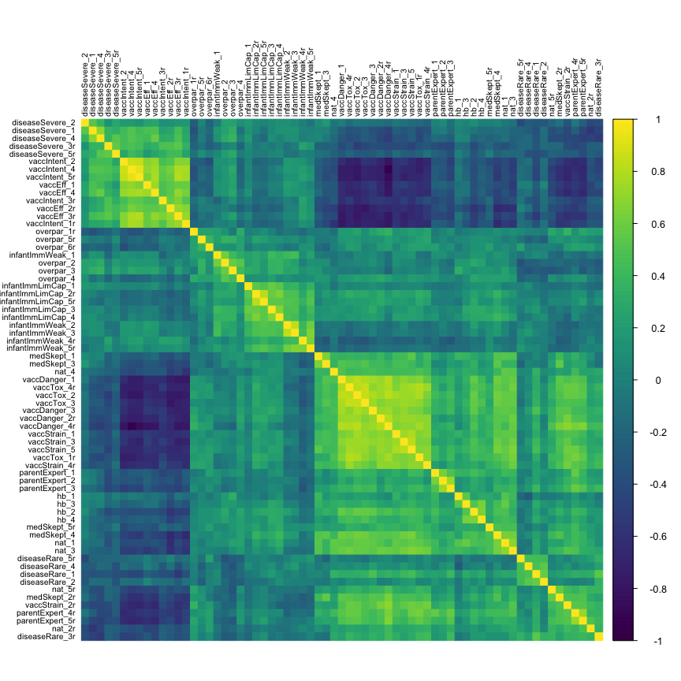

```r
corrplot(cor(df_main[,all_items]),
         order="hclust",
         # addrect=3,
         tl.cex=.65,
         tl.col="black",
         method="color",
         col=viridis(128))
```

# Scale Internal Consistency Reliability

# Problem scales

Below are computed chronbach’s alpha for all scales along with more detailed analyses of scales that are problematic.

## Disease Severity

Disease severe is now a weaker scale. I’d wager this is due to our changes, as this used to be highly reliable at $\alpha$ = .86.

```r
diseaseSevere <- all_items[20:24]
diseaseSevere.alpha <- psych::alpha(df[,diseaseSevere])
diseaseSevere.alpha$total$raw_alpha
```

```
[1] 0.7649575
```

```r
diseaseSevere.alpha
```

```
Reliability analysis
Call: psych::alpha(x = df[, diseaseSevere])

  raw_alpha std.alpha G6(smc) average_r S/N   ase mean   sd
      0.76      0.78     0.8      0.42 3.6 0.038  5.6 0.95

 lower alpha upper     95% confidence boundaries
0.69 0.76 0.84

 Reliability if an item is dropped:
                 raw_alpha std.alpha G6(smc) average_r S/N alpha se
diseaseSevere_1       0.68      0.70    0.68      0.37 2.4    0.053
diseaseSevere_2       0.77      0.79    0.78      0.48 3.7    0.038
diseaseSevere_3r      0.76      0.77    0.76      0.45 3.3    0.040
diseaseSevere_4       0.69      0.70    0.69      0.37 2.3    0.053
diseaseSevere_5r      0.71      0.74    0.72      0.41 2.8    0.049

 Item statistics
                  n raw.r std.r r.cor r.drop mean  sd
diseaseSevere_1  99  0.79  0.80  0.77   0.65  5.8 1.2
diseaseSevere_2  99  0.64  0.63  0.49   0.40  5.0 1.4
diseaseSevere_3r 99  0.70  0.67  0.55   0.46  5.5 1.6
diseaseSevere_4  99  0.79  0.81  0.78   0.67  6.0 1.1
diseaseSevere_5r 99  0.73  0.74  0.66   0.58  5.9 1.2

Non missing response frequency for each item
                    1    2    3    4    5    6    7 miss
diseaseSevere_1  0.01 0.01 0.01 0.12 0.16 0.32 0.36    0
diseaseSevere_2  0.02 0.02 0.03 0.37 0.16 0.19 0.20    0
diseaseSevere_3r 0.02 0.04 0.03 0.18 0.12 0.22 0.38    0
diseaseSevere_4  0.01 0.00 0.01 0.08 0.18 0.33 0.38    0
diseaseSevere_5r 0.00 0.01 0.03 0.11 0.18 0.27 0.39    0
```

### Diagnosing

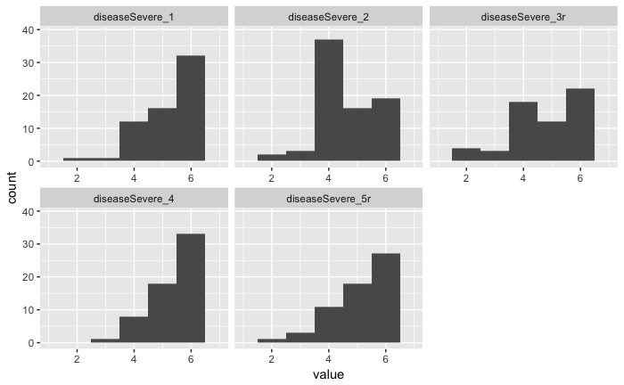

```r
library(ggplot2)
library(reshape2)
ggplot(data = melt(df[,diseaseSevere]), mapping = aes(x = value)) +
    geom_histogram(bins = 7) + facet_wrap(~variable, scales = 'free_x') + xlim(1,7)
```

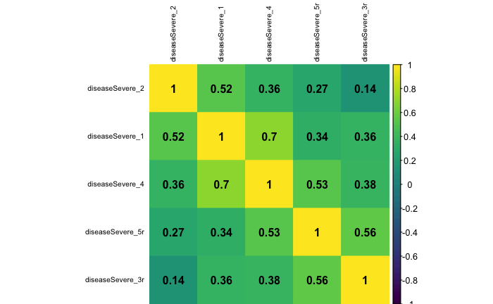

```r
corrplot(cor(df[,diseaseSevere]),
         order="AOE",
         tl.cex=.65,
         tl.col="black",
         method="color",
         addCoef.col="black",
         col=viridis(128))
```

## Naturalism

This scale took a hit – possibly due to the reverse coding? possibly just random variation. It went down from .825 so random variation is possible but seems on the extreme end.

```r
nat <- all_items[5:9]
naturalism.alpha <- psych::alpha(df[,nat])
naturalism.alpha$total$raw_alpha
```

```
[1] 0.7572042
```

```r
naturalism.alpha
```

```
Reliability analysis
Call: psych::alpha(x = df[, nat])

  raw_alpha std.alpha G6(smc) average_r S/N   ase mean  sd
      0.76      0.75    0.75      0.38   3 0.038  3.4 1.3

 lower alpha upper     95% confidence boundaries
0.68 0.76 0.83

 Reliability if an item is dropped:
       raw_alpha std.alpha G6(smc) average_r S/N alpha se
nat_1       0.67      0.67    0.64      0.33 2.0    0.054
nat_2r      0.75      0.75    0.73      0.42 2.9    0.040
nat_3       0.64      0.64    0.61      0.31 1.8    0.059
nat_4       0.71      0.71    0.70      0.38 2.5    0.047
nat_5r      0.77      0.76    0.74      0.44 3.2    0.037

 Item statistics
        n raw.r std.r r.cor r.drop mean  sd
nat_1  99  0.80  0.78  0.75   0.64  4.1 1.9
nat_2r 99  0.60  0.63  0.47   0.41  3.0 1.6
nat_3  99  0.84  0.83  0.81   0.70  3.9 1.9
nat_4  99  0.72  0.71  0.61   0.52  3.1 1.8
nat_5r 99  0.58  0.60  0.43   0.36  3.1 1.7

Non missing response frequency for each item
          1    2    3    4    5    6    7 miss
nat_1  0.13 0.11 0.09 0.20 0.22 0.13 0.11    0
nat_2r 0.19 0.24 0.19 0.21 0.09 0.04 0.03    0
nat_3  0.12 0.15 0.15 0.17 0.21 0.06 0.13    0
nat_4  0.25 0.24 0.09 0.20 0.08 0.08 0.05    0
nat_5r 0.24 0.14 0.19 0.29 0.03 0.03 0.07    0
```

```r
coefficientalpha::omega(df[,nat])
```

```
Test of homogeneity
The robust F statistic is  1.752
with a p-value  0.1305

The omega is 0.8071429.
About 10.1% of cases were downweighted.
```

## Overparenting with babies (new scale)

This got worse!

```r
overPar <- all_items[62:67]
# cor(df$immStrain_1,df$immStrain_2r)
overPar.alpha <- psych::alpha(df[,overPar])
overPar.alpha
```

```
Reliability analysis
Call: psych::alpha(x = df[, overPar])

  raw_alpha std.alpha G6(smc) average_r S/N   ase mean   sd
      0.71       0.7    0.72      0.28 2.4 0.045  3.8 0.97

 lower alpha upper     95% confidence boundaries
0.62 0.71 0.8

 Reliability if an item is dropped:
           raw_alpha std.alpha G6(smc) average_r S/N alpha se
overpar_1r      0.72      0.72    0.71      0.34 2.6    0.044
overpar_2       0.63      0.63    0.63      0.25 1.7    0.059
overpar_3       0.66      0.66    0.65      0.28 1.9    0.053
overpar_4       0.63      0.63    0.64      0.25 1.7    0.059
overpar_5r      0.66      0.65    0.66      0.27 1.8    0.054
overpar_6r      0.70      0.70    0.70      0.31 2.3    0.047

 Item statistics
            n raw.r std.r r.cor r.drop mean  sd
overpar_1r 99  0.48  0.49  0.33   0.26  3.1 1.4
overpar_2  99  0.73  0.72  0.68   0.56  4.4 1.6
overpar_3  99  0.65  0.64  0.58   0.46  4.8 1.5
overpar_4  99  0.73  0.72  0.65   0.55  3.8 1.6
overpar_5r 99  0.67  0.68  0.58   0.48  3.8 1.5
overpar_6r 99  0.54  0.56  0.40   0.33  2.8 1.4

Non missing response frequency for each item
              1    2    3    4    5    6    7 miss
overpar_1r 0.13 0.21 0.31 0.19 0.09 0.03 0.03    0
overpar_2  0.04 0.08 0.15 0.27 0.22 0.11 0.12    0
overpar_3  0.03 0.03 0.10 0.26 0.28 0.13 0.16    0
overpar_4  0.06 0.17 0.22 0.21 0.15 0.11 0.07    0
overpar_5r 0.04 0.16 0.21 0.28 0.15 0.10 0.05    0
overpar_6r 0.16 0.26 0.37 0.10 0.02 0.04 0.04    0
```

### Diagnosing

No clear fixes here, just not doing very well.

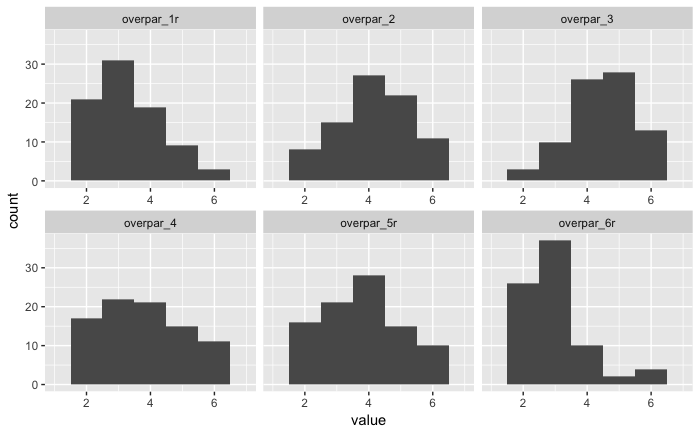

```r
ggplot(data = melt(df[,overPar]), mapping = aes(x = value)) +
    geom_histogram(bins = 7) + facet_wrap(~variable, scales = 'free_x') + xlim(1,7)
```

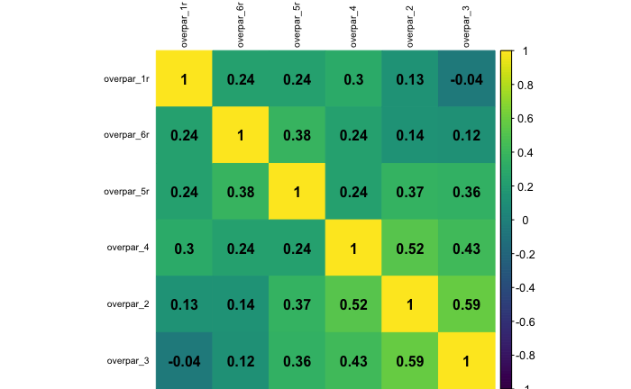

```r
corrplot(cor(df[,overPar]),
         order="AOE",
         tl.cex=.65,
         tl.col="black",
         method="color",
         addCoef.col="black",
         col=viridis(128))
```

# Acceptable scales

The remaining scales are (within rounding) in the acceptable reliabiltiy range.

## Holistic Balance

This reliability is lower but this scale is unchanged (and a pre-existing scale, so we should leave it alone).

```r
hb <- all_items[1:4]
hb.alpha <- psych::alpha(df[,hb])
hb.alpha$total$raw_alpha
```

```
[1] 0.7808182
```

## Disease Rarity

```r
diseaseRare <- all_items[15:19]
diseaseRare.alpha <- psych::alpha(df[,diseaseRare])
diseaseRare.alpha$total$raw_alpha
```

```
[1] 0.7970269
```

## Vaccine Effectiveness

```r
vaccEff <- all_items[25:28]
vaccEff.alpha <- psych::alpha(df[,vaccEff])
vaccEff.alpha$total$raw_alpha
```

```
[1] 0.872825
```

## Vaccine Danger

```r
vaccDanger <- all_items[29:32]
vaccDanger.alpha <- psych::alpha(df[,vaccDanger])
vaccDanger.alpha$total$raw_alpha
```

```
[1] 0.928215
```

## Vaccines are toxic

```r
vaccTox <- all_items[33:36]
vaccTox.alpha <- psych::alpha(df[,vaccTox])
vaccTox.alpha$total$raw
```

```
[1] 0.942404
```

## Medical Skepticism

This is just barely making the grade now. Removing 5r would improve the reliability. I thought the phrasing of that item was a bit awkward after reverse coding, so maybe it can be fixed.

```r
medSkept <- all_items[10:14]
medSkept.alpha <- psych::alpha(df[,medSkept])
medSkept.alpha$total$raw_alpha
```

```
[1] 0.7981024
```

```r
medSkept.alpha
```

```
Reliability analysis
Call: psych::alpha(x = df[, medSkept])

  raw_alpha std.alpha G6(smc) average_r S/N   ase mean  sd
       0.8       0.8    0.79      0.44   4 0.032  4.2 1.3

 lower alpha upper     95% confidence boundaries
0.73 0.8 0.86

 Reliability if an item is dropped:
            raw_alpha std.alpha G6(smc) average_r S/N alpha se
medSkept_1       0.75      0.75    0.73      0.43 3.0    0.041
medSkept_2r      0.76      0.76    0.74      0.44 3.1    0.041
medSkept_3       0.74      0.74    0.69      0.41 2.8    0.043
medSkept_4       0.73      0.73    0.71      0.40 2.7    0.045
medSkept_5r      0.82      0.81    0.78      0.52 4.4    0.030

 Item statistics
             n raw.r std.r r.cor r.drop mean  sd
medSkept_1  99  0.76  0.76  0.69   0.60  5.0 1.8
medSkept_2r 99  0.75  0.75  0.66   0.59  3.2 1.7
medSkept_3  99  0.79  0.79  0.75   0.65  4.0 1.8
medSkept_4  99  0.81  0.81  0.74   0.67  3.7 1.7
medSkept_5r 99  0.62  0.61  0.47   0.40  5.1 1.8

Non missing response frequency for each item
               1    2    3    4    5    6    7 miss
medSkept_1  0.04 0.08 0.06 0.20 0.19 0.15 0.27    0
medSkept_2r 0.18 0.22 0.22 0.16 0.11 0.03 0.07    0
medSkept_3  0.12 0.08 0.12 0.33 0.15 0.07 0.12    0
medSkept_4  0.10 0.20 0.12 0.30 0.10 0.08 0.09    0
medSkept_5r 0.05 0.05 0.08 0.19 0.16 0.15 0.31    0
```

## Vaccination Intentions

```r
vaccIntent <- all_items[42:46]
vaccIntent.alpha <- psych::alpha(df[,vaccIntent])
vaccIntent.alpha$total$raw_alpha
```

```
[1] 0.9184105
```

## Parental Expertise

Success! Reliability is very solid.

```r
parExpert <- all_items[47:51]
parExpert.alpha <- psych::alpha(df[,parExpert])
parExpert.alpha$total$raw_alpha
```

```
[1] 0.8564435
```

```r
parExpert.alpha
```

```
Reliability analysis
Call: psych::alpha(x = df[, parExpert])

  raw_alpha std.alpha G6(smc) average_r S/N   ase mean  sd
      0.86      0.86    0.87      0.54   6 0.023  3.3 1.3

 lower alpha upper     95% confidence boundaries
0.81 0.86 0.9

 Reliability if an item is dropped:
                raw_alpha std.alpha G6(smc) average_r S/N alpha se
parentExpert_1       0.83      0.84    0.84      0.56 5.1    0.028
parentExpert_2       0.82      0.83    0.80      0.54 4.8    0.029
parentExpert_3       0.81      0.81    0.81      0.52 4.3    0.031
parentExpert_4r      0.82      0.81    0.80      0.52 4.3    0.030
parentExpert_5r      0.84      0.84    0.84      0.58 5.4    0.026

 Item statistics
                 n raw.r std.r r.cor r.drop mean  sd
parentExpert_1  99  0.78  0.77  0.70   0.64  4.2 1.7
parentExpert_2  99  0.81  0.80  0.76   0.68  3.5 1.7
parentExpert_3  99  0.84  0.83  0.79   0.73  3.0 1.7
parentExpert_4r 99  0.83  0.83  0.80   0.71  3.3 1.7
parentExpert_5r 99  0.73  0.75  0.68   0.60  2.6 1.4

Non missing response frequency for each item
                   1    2    3    4    5    6    7 miss
parentExpert_1  0.10 0.09 0.10 0.19 0.33 0.10 0.08    0
parentExpert_2  0.15 0.19 0.15 0.19 0.21 0.07 0.03    0
parentExpert_3  0.22 0.26 0.13 0.13 0.17 0.07 0.01    0
parentExpert_4r 0.16 0.22 0.17 0.21 0.13 0.05 0.05    0
parentExpert_5r 0.25 0.28 0.21 0.17 0.05 0.01 0.02    0
```

Looks a little two-dimensional though. Items 4 and 5 are both about trusing doctors’ advice, so I suppose it’s not surprising they hang together even more strongly.

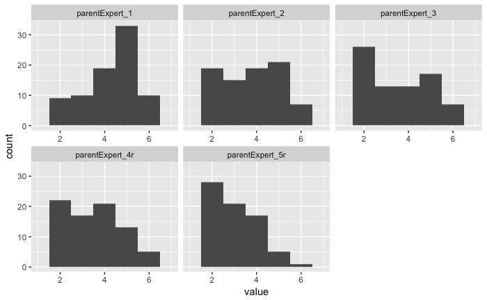

```r
library(ggplot2)
library(reshape2)
ggplot(data = melt(df[,parExpert]), mapping = aes(x = value)) +
    geom_histogram(bins = 7) + facet_wrap(~variable, scales = 'free_x') + xlim(1,7)
```

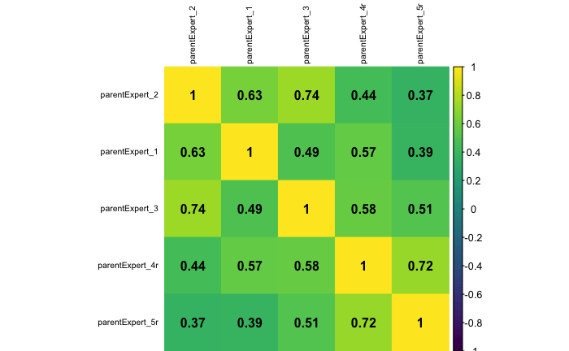

```r
corrplot(cor(df[,parExpert]),
         order="AOE",
         tl.cex=.65,
         tl.col="black",
         method="color",
         addCoef.col="black",
         col=viridis(128))
```

## Infant immune system has limited capacity

Reliability is now very good.

```r
immCap <- all_items[52:56]
immCap.alpha <- psych::alpha(df[,immCap])
immCap.alpha$total$raw_alpha
```

```
[1] 0.8788183
```

```r
immCap.alpha
```

```
Reliability analysis
Call: psych::alpha(x = df[, immCap])

  raw_alpha std.alpha G6(smc) average_r S/N   ase mean  sd
      0.88      0.88    0.88      0.59 7.2 0.019  4.2 1.2

 lower alpha upper     95% confidence boundaries
0.84 0.88 0.92

 Reliability if an item is dropped:
                   raw_alpha std.alpha G6(smc) average_r S/N alpha se
infantImmLimCap_1       0.87      0.87    0.87      0.63 6.9    0.021
infantImmLimCap_2r      0.83      0.83    0.80      0.56 5.0    0.028
infantImmLimCap_3       0.85      0.85    0.84      0.59 5.8    0.024
infantImmLimCap_4       0.85      0.85    0.84      0.59 5.7    0.025
infantImmLimCap_5r      0.85      0.85    0.82      0.59 5.7    0.024

 Item statistics
                    n raw.r std.r r.cor r.drop mean  sd
infantImmLimCap_1  99  0.76  0.76  0.66   0.62  4.5 1.4
infantImmLimCap_2r 99  0.88  0.87  0.86   0.79  4.0 1.5
infantImmLimCap_3  99  0.81  0.82  0.76   0.71  3.9 1.3
infantImmLimCap_4  99  0.83  0.82  0.77   0.72  4.4 1.5
infantImmLimCap_5r 99  0.83  0.82  0.79   0.72  4.2 1.4

Non missing response frequency for each item
                      1    2    3    4    5    6    7 miss
infantImmLimCap_1  0.01 0.08 0.11 0.29 0.27 0.13 0.10    0
infantImmLimCap_2r 0.05 0.10 0.20 0.31 0.14 0.13 0.06    0
infantImmLimCap_3  0.04 0.14 0.10 0.42 0.18 0.08 0.03    0
infantImmLimCap_4  0.02 0.11 0.12 0.28 0.23 0.15 0.08    0
infantImmLimCap_5r 0.01 0.10 0.17 0.37 0.13 0.14 0.07    0
```

## Infants’ immune systems are weak

Looks good!

```r
immWeak <- all_items[57:61]
immWeak.alpha <- psych::alpha(df[,immWeak])
immWeak.alpha$total$raw_alpha
```

```
[1] 0.8172379
```

```r
immWeak.alpha
```

```
Reliability analysis
Call: psych::alpha(x = df[, immWeak])

  raw_alpha std.alpha G6(smc) average_r S/N  ase mean  sd
      0.82      0.82    0.84      0.48 4.6 0.03  4.3 1.2

 lower alpha upper     95% confidence boundaries
0.76 0.82 0.88

 Reliability if an item is dropped:
                 raw_alpha std.alpha G6(smc) average_r S/N alpha se
infantImmWeak_1       0.86      0.85    0.86      0.59 5.9    0.025
infantImmWeak_2       0.74      0.74    0.75      0.42 2.9    0.044
infantImmWeak_3       0.72      0.73    0.73      0.40 2.7    0.046
infantImmWeak_4r      0.82      0.82    0.82      0.54 4.6    0.031
infantImmWeak_5r      0.75      0.75    0.77      0.44 3.1    0.041

 Item statistics
                  n raw.r std.r r.cor r.drop mean  sd
infantImmWeak_1  99  0.59  0.58  0.41   0.36  4.2 1.7
infantImmWeak_2  99  0.85  0.85  0.84   0.75  4.5 1.6
infantImmWeak_3  99  0.88  0.88  0.89   0.80  4.5 1.5
infantImmWeak_4r 99  0.66  0.67  0.57   0.48  4.2 1.5
infantImmWeak_5r 99  0.82  0.83  0.79   0.70  4.0 1.6

Non missing response frequency for each item
                    1    2    3    4    5    6    7 miss
infantImmWeak_1  0.06 0.11 0.20 0.16 0.20 0.18 0.08    0
infantImmWeak_2  0.05 0.06 0.14 0.25 0.23 0.15 0.11    0
infantImmWeak_3  0.02 0.10 0.16 0.15 0.28 0.20 0.08    0
infantImmWeak_4r 0.01 0.11 0.22 0.32 0.13 0.10 0.10    0
infantImmWeak_5r 0.05 0.10 0.23 0.32 0.07 0.14 0.08    0
```

## Vaccines strain the immune system

Now with five items this makes for a very reliable scale.

```r
vaccStrain <- all_items[37:41]
# cor(df$immStrain_1,df$immStrain_2r)
vaccStrain.alpha <- psych::alpha(df[,vaccStrain])
vaccStrain.alpha
```

```
Reliability analysis
Call: psych::alpha(x = df[, vaccStrain])

  raw_alpha std.alpha G6(smc) average_r S/N   ase mean  sd
      0.91      0.91     0.9      0.66 9.8 0.015  3.4 1.4

 lower alpha upper     95% confidence boundaries
0.88 0.91 0.94

 Reliability if an item is dropped:
              raw_alpha std.alpha G6(smc) average_r  S/N alpha se
vaccStrain_1       0.88      0.88    0.87      0.65  7.6    0.020
vaccStrain_2r      0.92      0.92    0.90      0.73 10.8    0.014
vaccStrain_3       0.88      0.88    0.86      0.65  7.3    0.020
vaccStrain_4r      0.88      0.89    0.87      0.66  7.8    0.020
vaccStrain_5       0.87      0.87    0.85      0.62  6.6    0.022

 Item statistics
               n raw.r std.r r.cor r.drop mean  sd
vaccStrain_1  99  0.87  0.87  0.84   0.78  3.4 1.7
vaccStrain_2r 99  0.77  0.76  0.67   0.63  3.1 1.8
vaccStrain_3  99  0.88  0.88  0.85   0.80  3.1 1.7
vaccStrain_4r 99  0.85  0.86  0.81   0.77  3.7 1.6
vaccStrain_5  99  0.91  0.91  0.90   0.85  3.6 1.7

Non missing response frequency for each item
                 1    2    3    4    5    6    7 miss
vaccStrain_1  0.13 0.20 0.20 0.21 0.11 0.09 0.05    0
vaccStrain_2r 0.22 0.20 0.20 0.19 0.04 0.08 0.06    0
vaccStrain_3  0.20 0.27 0.13 0.18 0.13 0.04 0.04    0
vaccStrain_4r 0.09 0.16 0.15 0.35 0.11 0.04 0.09    0
vaccStrain_5  0.10 0.21 0.13 0.30 0.09 0.11 0.05    0
```

# Scale Distributions

```r
df_scales<-df_main
df_scales$holBalance <- rowMeans(df[,hb])
df_scales$naturalism <- rowMeans(df[,nat])
df_scales$diseaseRare <- rowMeans(df[,diseaseRare])
df_scales$diseaseSevere <- rowMeans(df[,diseaseSevere])
df_scales$vaccEff <- rowMeans(df[,vaccEff])
df_scales$vaccDanger <- rowMeans(df[,vaccDanger])
df_scales$medSkept <- rowMeans(df[,medSkept])
df_scales$vaccIntent <- rowMeans(df[,vaccIntent])
# df_scales$parDuty <- rowMeans(df[,parDuty])
df_scales$parExpert <- rowMeans(df[,parExpert])
df_scales$immCap <- rowMeans(df[,immCap])
# df_scales$immSympt <- rowMeans(df[,immSympt])
df_scales$immWeak <- rowMeans(df[,immWeak])
df_scales$vaccStrain <- rowMeans(df[,vaccStrain])
df_scales$vaccTox <- rowMeans(df[,vaccTox])
df_scales$overParenting <- rowMeans(df[,overPar])
```

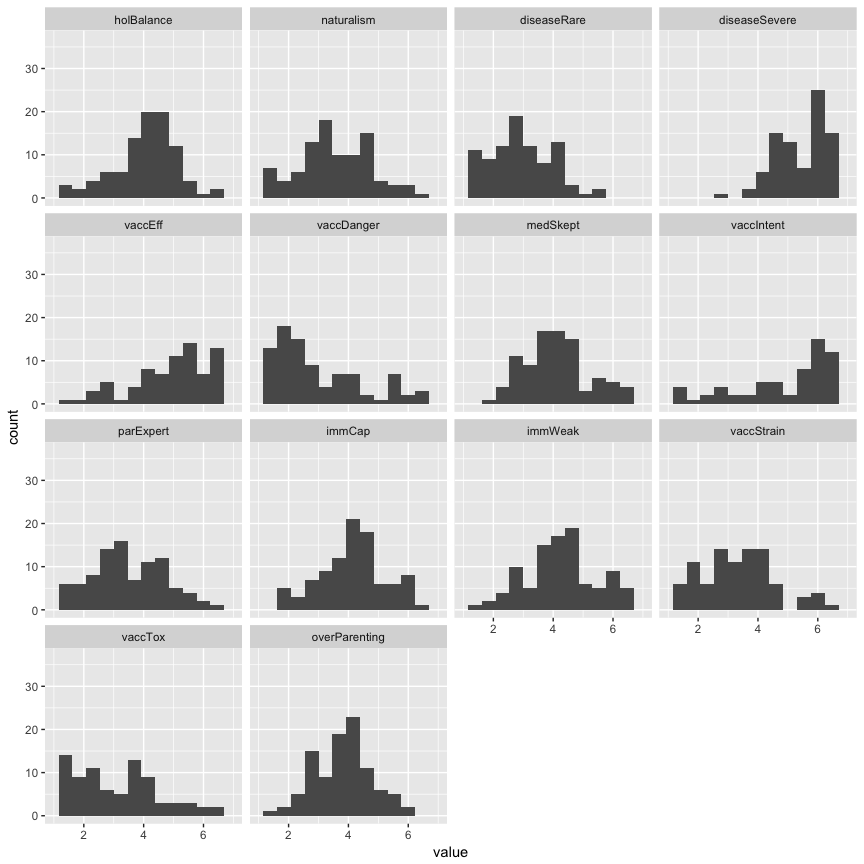

```r
library(ggplot2)
library(reshape2)
scale_vars <- c("holBalance",
                "naturalism",
                "diseaseRare",
                "diseaseSevere",
                "vaccEff",
                "vaccDanger",
                "medSkept",
                "vaccIntent",
                "parExpert",
                "immCap",
                "immWeak",
                "vaccStrain",
                "vaccTox",
                "overParenting")
# df_hist <- df_scales[,scale_vars]
plt.hist <- ggplot(data = melt(df_scales[,scale_vars]), mapping = aes(x = value)) +
    geom_histogram(bins = 14) + facet_wrap(~variable) + xlim(1,7)
# ggsave("scale_hists.png",plt.hist)
plt.hist
```

# Scale correlations

Some of this is expected and some is a bit surprising. Of course once we start taking into account other conditional dependencies, some of these correlations could change, or even reverse sign.

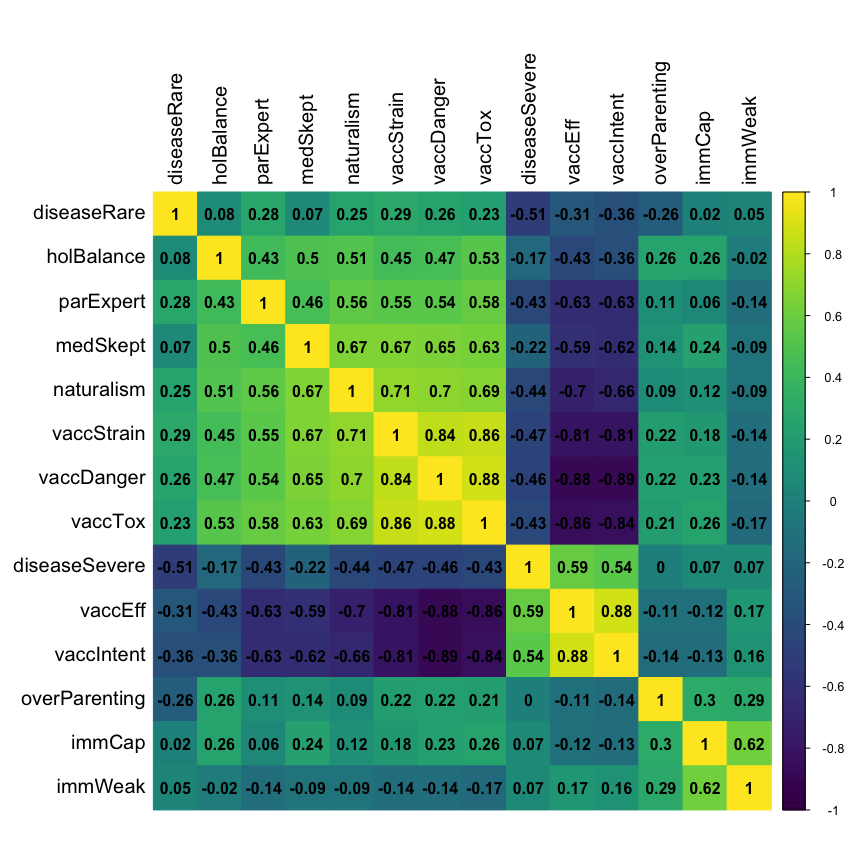

```r
corrplot(cor(df_scales[,scale_vars]),
         order="hclust",
         tl.cex=1.25,
         tl.col="black",
         method="color",
         addCoef.col="black",
         col=viridis(128))
```

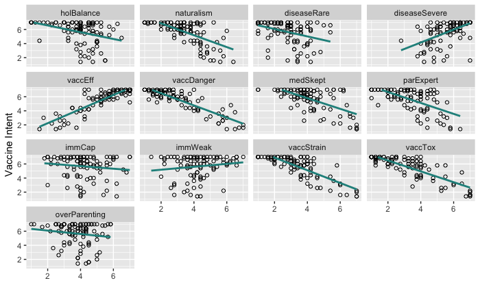

```r
df_long <- df_scales
df_long$y_val <- df_long$vaccIntent
df_long <- reshape(df_long, idvar="workerId", timevar = "item", direction="long",
             varying=list(x_val = scale_vars[-8]),
             v.names = c("x_val"))
df_long$item <- factor(df_long$item,
                       levels = seq(1,13,1),
                       labels=scale_vars[-8])
plt.scatter <- ggplot(data = df_long, mapping = aes(x = x_val, y=y_val)) +
    geom_point(shape=1) +
  geom_smooth(method="lm", se=FALSE, col=viridis_pal()(5)[3]) +
  facet_wrap(~item) +
  xlim(1,7) + ylim(1,7) + labs(y="Vaccine Intent", x="")
# ggsave("scale_scatter.png",plt.scatter)
plt.scatter
```

# Coefficient $\omega$ reliability

Coefficient $\alpha$ has a number of well-known problems, not the least of which it is often biased (either under or over-estimating). Most people who know now recommend the use of coeffiicent $\omega$, because it is unbiased and also readily interpretable: $\omega$ represents the proportion of variance in scale scores accounted for by the latent factor.

Here I’m calculating robust $\omega$ using the coefficientalpha package. A (non-robust?) implementation is also available in the psych package that relies on an SEM package.

If $\omega$ is to be trusted it looks like the bias in $\alpha$ is leading to an underestimate of the reliability of most scales.

## Naturalism

```r
coefficientalpha::omega(df[,nat])
```

```
Test of homogeneity
The robust F statistic is  1.752
with a p-value  0.1305

The omega is 0.8071429.
About 10.1% of cases were downweighted.
```

## DiseaseSeverity

```r
coefficientalpha::omega(df[,diseaseSevere])
```

```
Test of homogeneity
The robust F statistic is  1.872
with a p-value  0.1066

The omega is 0.8145063.
About 21.21% of cases were downweighted.
```

## Over-parenting

Still poor.

```r
coefficientalpha::omega(df[,overPar])
```

```
Test of homogeneity
The robust F statistic is  2.674
with a p-value  0.0085

**The F test rejected homogeneity**

The omega is 0.7462275.
About 12.12% of cases were downweighted.
```

## Medical skepticism

```r
coefficientalpha::omega(df[,medSkept])
```

```
Test of homogeneity
The robust F statistic is  2.668
with a p-value  0.0267

**The F test rejected homogeneity**

The omega is 0.8153402.
About 12.12% of cases were downweighted.
```

## Disease Rarity

```r
coefficientalpha::omega(df[,diseaseRare])
```

```
Test of homogeneity
The robust F statistic is  0.63
with a p-value  0.6771

The omega is 0.8300444.
About 16.16% of cases were downweighted.
```